# 🧑‍🏫 Data Analysis with Pandas & Matplotlib

In this notebook, we'll explore a real-world dataset of student performance using Python libraries like `pandas` and `matplotlib`. You'll learn how to load, clean, analyze, visualize, and create new features from the data.

## ✅ Step 1: Import Libraries

We begin by importing the necessary libraries for data handling and visualization.

```python
import pandas as pd
import matplotlib.pyplot as plt
```

### 🧾 Common Pandas Functions Explained

- **`df.head()`** – Shows the first 5 rows of the dataset to get a quick preview of the data.
- **`df.tail()`** – Displays the last 5 rows of the dataset, useful for checking the end of the data.
- **`df.info()`** – Summarizes the dataset, showing column names, data types, and missing values.
- **`df.shape`** – Returns the number of rows and columns in the dataset as a tuple.
- **`df.columns`** – Lists all the column names in the dataset.
- **`df.dtypes`** – Shows the data type (e.g., int, float, object) for each column.
- **`df.describe()`** – Provides summary statistics (like mean, min, max) for numerical columns.
- **`df.isnull()`** – Returns a DataFrame showing where missing (`NaN`) values are located (True/False).
- **`df.rename()`** – Renames columns or indexes using a dictionary of old and new names.
- **`df.sort_values()`** – Sorts the DataFrame by one or more columns, either ascending or descending.
- **`df.loc[]`** – Accesses rows or columns by label (name).
- **`df.iloc[]`** – Accesses rows or columns by index position.
- **`df['column'].unique()`** – Returns all unique values found in a specific column.
- **`df.sample()`** – Randomly selects rows from the dataset, useful for quick previews or testing.

## 📂 Step 2: Load the Dataset

Let's load the dataset that we downloaded from Kaggle.

```python
df = pd.read_csv("StudentsPerformance.csv")
```

```python
df.head()
```

|  | gender | race/ethnicity | parental level of education | lunch | test preparation course | math score | reading score | writing score |
| --- | --- | --- | --- | --- | --- | --- | --- | --- |
| 0 | female | group B | bachelor's degree | standard | none | 72 | 72 | 74 |
| 1 | female | group C | some college | standard | completed | 69 | 90 | 88 |
| 2 | female | group B | master's degree | standard | none | 90 | 95 | 93 |
| 3 | male | group A | associate's degree | free/reduced | none | 47 | 57 | 44 |
| 4 | male | group C | some college | standard | none | 76 | 78 | 75 |

```python
df.tail()
```

|  | gender | race/ethnicity | parental level of education | lunch | test preparation course | math score | reading score | writing score |
| --- | --- | --- | --- | --- | --- | --- | --- | --- |
| 995 | female | group E | master's degree | standard | completed | 88 | 99 | 95 |
| 996 | male | group C | high school | free/reduced | none | 62 | 55 | 55 |
| 997 | female | group C | high school | free/reduced | completed | 59 | 71 | 65 |
| 998 | female | group D | some college | standard | completed | 68 | 78 | 77 |
| 999 | female | group D | some college | free/reduced | none | 77 | 86 | 86 |

`Select the row with label/index 0 and view specific columns`

```python
df.loc[0, ['gender', 'math score']]
```

```
gender        female
math score        72
Name: 0, dtype: object
```

`Select rows and columns by index position (row 0 to 4, columns 0 to 2):`

```python
df.iloc[0:5, 0:3]
```

|  | gender | race/ethnicity | parental level of education |
| --- | --- | --- | --- |
| 0 | female | group B | bachelor's degree |
| 1 | female | group C | some college |
| 2 | female | group B | master's degree |
| 3 | male | group A | associate's degree |
| 4 | male | group C | some college |

## 📋 Step 3: Understand the Structure of the Data

`Let's check the structure, column names, and if we have any missing values.`

```python
df.info()
```

```
<class 'pandas.core.frame.DataFrame'>
RangeIndex: 1000 entries, 0 to 999
Data columns (total 8 columns):
 #   Column                       Non-Null Count  Dtype
---  ------                       --------------  -----
 0   gender                       1000 non-null   object
 1   race/ethnicity               1000 non-null   object
 2   parental level of education  1000 non-null   object
 3   lunch                        1000 non-null   object
 4   test preparation course      1000 non-null   object
 5   math score                   1000 non-null   int64
 6   reading score                1000 non-null   int64
 7   writing score                1000 non-null   int64
dtypes: int64(3), object(5)
memory usage: 62.6+ KB
```

`Check number of rows and columns with df.shape`

```python
df.shape
```

```
(1000, 8)
```

`Check columns in dataset:`

```python
df.columns
```

```
Index(['gender', 'race/ethnicity', 'parental level of education', 'lunch',
       'test preparation course', 'math score', 'reading score',
       'writing score'],
      dtype='object')
```

`Check column data types:`

```python
df.dtypes
```

```
gender                         object
race/ethnicity                 object
parental level of education    object
lunch                          object
test preparation course        object
math score                      int64
reading score                   int64
writing score                   int64
dtype: object
```

`See all unique values in a categorical column:`

```python
df['race/ethnicity'].unique()
```

```
array(['group B', 'group C', 'group A', 'group D', 'group E'],
      dtype=object)
```

`Get 3 random rows from the dataset:`

```python
df.sample(3)
```

|  | gender | race/ethnicity | parental level of education | lunch | test preparation course | math score | reading score | writing score |
| --- | --- | --- | --- | --- | --- | --- | --- | --- |
| 227 | male | group D | high school | standard | none | 57 | 50 | 54 |
| 605 | male | group C | some high school | standard | none | 75 | 72 | 62 |
| 366 | male | group C | high school | standard | completed | 69 | 58 | 53 |

## 📉 Step 4: Descriptive Statistics

We use `.describe()` to quickly see some statistical summaries of the numerical columns.

```python
df.describe()
```

|  | math score | reading score | writing score |
| --- | --- | --- | --- |
| count | 1000.00000 | 1000.000000 | 1000.000000 |
| mean | 66.08900 | 69.169000 | 68.054000 |
| std | 15.16308 | 14.600192 | 15.195657 |
| min | 0.00000 | 17.000000 | 10.000000 |
| 25% | 57.00000 | 59.000000 | 57.750000 |
| 50% | 66.00000 | 70.000000 | 69.000000 |
| 75% | 77.00000 | 79.000000 | 79.000000 |
| max | 100.00000 | 100.000000 | 100.000000 |

### 🧩 Missing Values and How to Check for Them

Missing values occur when some data is not recorded or is unavailable, and they are often represented as `NaN` (Not a Number) in a dataset. These missing entries can affect the accuracy of your analysis or any machine learning models you might build, so it's important to detect and handle them appropriately.

In pandas, you can check for missing values using the `df.isnull()` function, which returns a DataFrame showing `True` for missing values and `False` otherwise. To get a quick summary of how many values are missing in each column, you can use `df.isnull().sum()`, which helps identify which columns might need cleaning or imputation before analysis.

```python
df.isnull().sum()
```

```
gender                         0
race/ethnicity                 0
parental level of education    0
lunch                          0
test preparation course        0
math score                     0
reading score                  0
writing score                  0
dtype: int64
```

#### `Remove Missing Values`

```python
df_clean = df.dropna()
```

## 🧹 Step 5: Clean Column Names

Change Column Names

```python
df=df.rename(columns={"race/ethnicity":"race_ethnicity",
                      "parental level of education":"Education",
                      "test preparation course":"test_preparation_course",
                      "math score":"math_score",
                      "reading score":"reading_score",
                      "writing score":"writing_score"})
df.head()
```

|  | gender | race_ethnicity | Education | lunch | test_preparation_course | math_score | reading_score | writing_score |
| --- | --- | --- | --- | --- | --- | --- | --- | --- |
| 0 | female | group B | bachelor's degree | standard | none | 72 | 72 | 74 |
| 1 | female | group C | some college | standard | completed | 69 | 90 | 88 |
| 2 | female | group B | master's degree | standard | none | 90 | 95 | 93 |
| 3 | male | group A | associate's degree | free/reduced | none | 47 | 57 | 44 |
| 4 | male | group C | some college | standard | none | 76 | 78 | 75 |

## 🔍 Step 6: Explore Categorical Columns

Let’s see the distribution of values for some categorical features.

`Categorical columns` are variables in a dataset that contain a limited number of distinct values or categories, often representing groups or labels such as "gender", "race/ethnicity", or "test preparation course". These columns are typically used to group, filter, or compare data rather than perform numerical calculations.

```python
df['gender'].value_counts()
```

```
female    518
male      482
Name: gender, dtype: int64
```

```python
df['Education'].value_counts()
```

```
some college          226
associate's degree    222
high school           196
some high school      179
bachelor's degree     118
master's degree        59
Name: Education, dtype: int64
```

## 📊 Step 7: Visualize the Data

We will create some plots to better understand the data.

### 7.1 Histogram of Math Scores

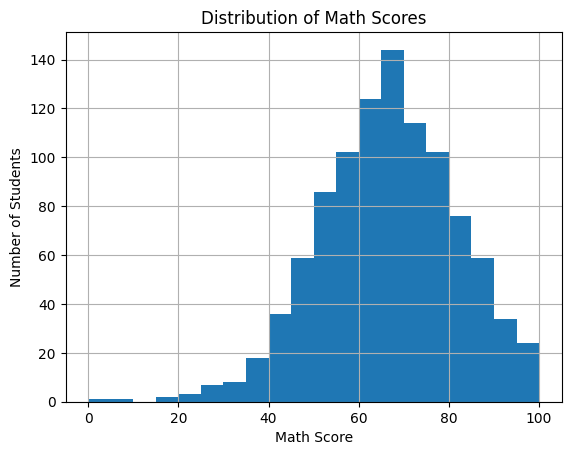

```python
df['math_score'].hist(bins=20)
plt.title("Distribution of Math Scores")
plt.xlabel("Math Score")
plt.ylabel("Number of Students")
```

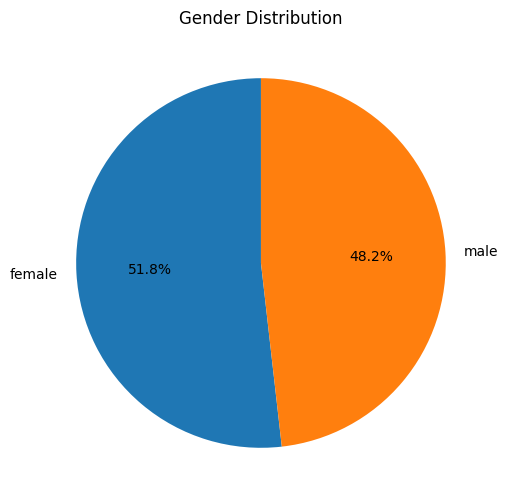

```python
gender_counts = df['gender'].value_counts()
plt.figure(figsize=(6,6))
plt.pie(gender_counts, labels=gender_counts.index, autopct='%1.1f%%', startangle=90)
plt.title('Gender Distribution')
plt.show()
```

## 📈 Step 8: Group Analysis

### `What is Group Analysis and groupby in Pandas?`

Group analysis is a technique used in data analysis to summarize or compare data based on categories (groups). For example, you might want to compare average math scores between males and females, or see how students from different education backgrounds perform.

In pandas, we use the .groupby() function to do this. It allows you to:

- Group data based on the values in one or more columns.
- Apply a function like .mean(), .sum(), .count(), etc., to each group.

```python
df.groupby('gender')['math_score'].mean()
```

```
gender
female    63.633205
male      68.728216
Name: math_score, dtype: float64
```

`This line of code:`

- Groups the data by the gender column.
- Calculates the average (mean) math score for each gender group.

### `Why is it useful?`

- It helps reveal patterns or differences between groups.
- It’s used in exploratory data analysis to ask and answer questions like:
- Does test preparation improve scores?
- Do students from different ethnic groups perform differently?
- Does gender affect the average score?

## 🧠 Step 9: Create New Features

In data analysis, creating new features means generating additional columns in your dataset that are derived from existing data. This helps uncover hidden patterns and makes the dataset more useful for analysis or machine learning.

### `Why create new features?`

- To summarize multiple columns (e.g., average of test scores)
- To categorize values (e.g., pass/fail based on score)
- To add context or make comparisons easier

```python
df['average_score'] = df[['math_score', 'reading_score', 'writing_score']].mean(axis=1)
```

```python
df['passed'] = df['average_score'] >= 60
df['passed'].value_counts()
```

```
True     715
False    285
Name: passed, dtype: int64
```

```python
df['passed'] = df['passed'].map({True: "yes", False: "no"})
df['passed']
```

```
0      yes
1      yes
2      yes
3       no
4      yes
      ...
995    yes
996     no
997    yes
998    yes
999    yes
Name: passed, Length: 1000, dtype: object
```

## 📊 Step 10: Group by Parent Education

Let’s see how parental education level relates to average score.

```python
df.groupby('Education')['average_score'].mean().sort_values()
```

```
Education
high school           63.096939
some high school      65.108007
some college          68.476401
associate's degree    69.569069
bachelor's degree     71.923729
master's degree       73.598870
Name: average_score, dtype: float64
```

## 📉 Step 11 (Optional): Correlation Heatmap

Visualizing relationships between numeric features.

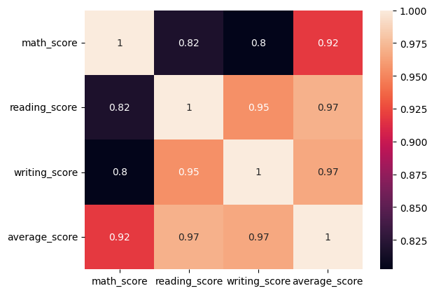

```python
import seaborn as sns
sns.heatmap(df[['math_score', 'reading_score', 'writing_score', 'average_score']].corr(), annot=True)
```

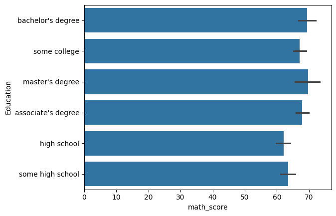

```python
sns.barplot(data=df, x="math_score", y="Education")
plt.show()
```

## 💬 Mini Activity

`Try answering the following questions using code:`

1. Create a bar plot showing average score by gender.
2. Plot the distribution of writing scores.

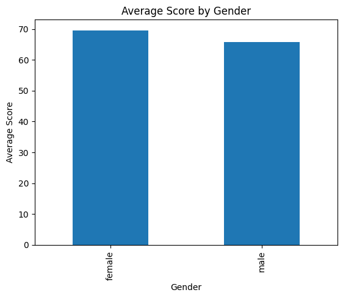

```python
avg_score_by_gender = df.groupby('gender')['average_score'].mean()
avg_score_by_gender.plot(kind='bar')
plt.title("Average Score by Gender")
plt.ylabel("Average Score")
plt.xlabel("Gender")
plt.show()
```

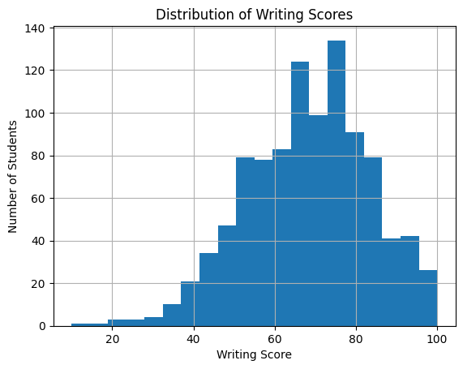

```python
df['writing_score'].hist(bins=20)
plt.title("Distribution of Writing Scores")
plt.xlabel("Writing Score")
plt.ylabel("Number of Students")
plt.show()
```

## Write Final Results to a new file

```python
df.to_csv("StudentsPerformance_cleaned.csv", index=False)
```

## 🎯 What You've Learned

- How to load and explore a dataset using `pandas`
- How to visualize data using `matplotlib`
- How to clean and transform data
- How to create new meaningful features
- How to group and aggregate data for insights